# First Assignment - SMDE

Ricard Meyerhofer Parra

5/10/2018

# 1 Table of contents

1. First Question
2. Second Question
3. Third Question
4. Fourth Question

## 1.1 FIRST QUESTION: GENERATE A RANDOM SAMPLE

In this question we are going to generate multiple random samples with different sizes from the codes provided in the assignment.

The first one we are going to use is Mersenne Twister random generator with one of the parametrations (the first one) that pass the Diehard Battery of Tests of Randomness:

```cpp
//First parametrization
unsigned long init[LENGTH]={
0x631f1690, 0x25973e32, 0xead6f57, 0x6ec9d844, 0x5c49eaee,
0x64af49b, 0x397c46bc, 0x7e448de9, 0x5a9cc3e5, 0x1afe3625,
0x3ca88ecf, 0x6ebe4208, 0xc058df5, 0xcbe5be9, 0x3102bbe2,
0x26a02c5e, 0x541c8153, 0x67906f60, 0x10db9daa, 0x697d2d2,
0x6d68ab2, 0x3a966cd0, 0x63f37e85, 0x5895f5fa, 0x38a5d054};
```

Once execute the algorithm, we are going to save the output as a .csv and we will load it in R so that we can start manipulating the data.

```r
setwd("C:/Users/Meyerhofer/Desktop/SMDELabs")
mersenne_twister <- read.csv("samples.csv", sep = "\t", header = F)
```

```r
mersenne_twister_class = transform(mersenne_twister, cat2 = ifelse(V1 < 0,"0",
                                                                   ifelse(V1 < 0.2,"0.2",
                                                                   ifelse(V1 < 0.4,"0.4",
                                                                   ifelse(V1 < 0.6,"0.6",
                                                                   ifelse(V1 < 0.8,"0.8","1"))))))
mersenne_freqs = as.data.frame(with(mersenne_twister_class, table(cat2)))
```

Similarly, we create another data sample with a uniform distribution which as Mersenne’s Algorithm has values between 0 and 1. This dataset will also be segmented according the same labels we previously used for Mersenne. Note that to make the sample reproducible, we are using a seed.

```r
set.seed(1234)
v1=runif(200, min = 0, max = 1)
summary(v1)
```

```
##     Min.  1st Qu.   Median     Mean  3rd Qu.     Max.
## 0.009496 0.237935 0.485563 0.483286 0.734949 0.998741
```

```r
#Work with the data as a dataframe.
taula_v1=data.frame(x1=v1)

#Definition of the intervals, categories to be used.
taula_v1_cat=transform(taula_v1, cat1 = ifelse(x1 < 0,"0",
                                               ifelse(x1 < 0.2,"0.2",
                                               ifelse(x1 < 0.4,"0.4",
                                               ifelse(x1 < 0.6,"0.6",
                                               ifelse(x1 < 0.8,"0.8","1"))))))
```

Finally we aggregate both frequencies in a same dataframe. In order to have a first vision if they are similar, we do two barplots:

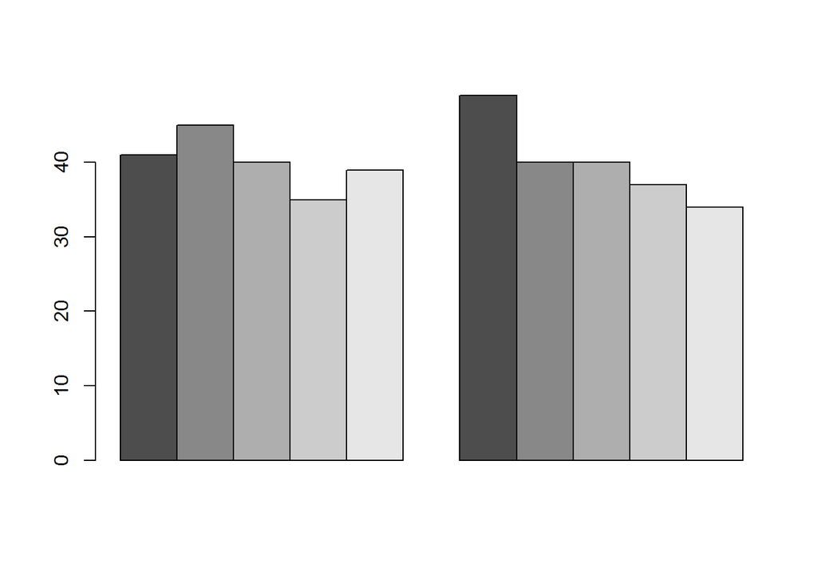

```r
#Counting the amount of elements in each category “table” function.
taula_freq_v1=as.data.frame(with(taula_v1_cat, table(cat1)))

taula_freq = rbind(taula_freq_v1$Freq, mersenne_freqs$Freq)

aux = cbind(taula_freq_v1$Freq, mersenne_freqs$Freq)

barplot(aux, beside=T)
```

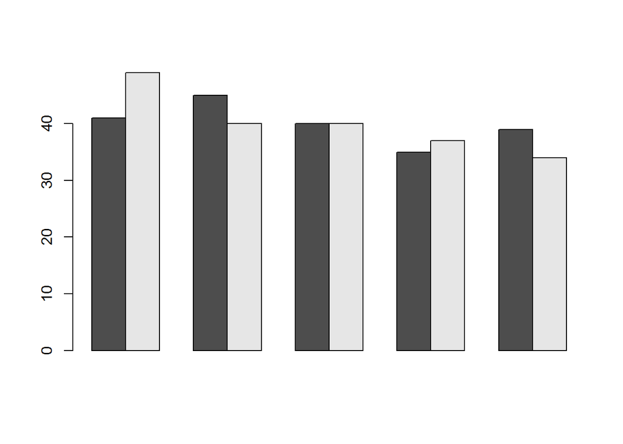

```r
barplot(taula_freq,beside=T)
```

Now that we have this generator created and we already have the data as we want. We are going to see if it follows a uniform distribution by applying a chi square test.

[output not shown]